# Clustering Practice

Using dplyr, tidyr and other packages

First, we will practice with R built-in datasets, like USArrests

```r
data("USArrests")
arrests_df = USArrests %>%
  as_tibble()
arrests_df
```

```
## # A tibble: 50 x 4
##    Murder Assault UrbanPop  Rape
##     <dbl>   <int>    <int> <dbl>
##  1   13.2     236       58  21.2
##  2   10       263       48  44.5
##  3    8.1     294       80  31
##  4    8.8     190       50  19.5
##  5    9       276       91  40.6
##  6    7.9     204       78  38.7
##  7    3.3     110       77  11.1
##  8    5.9     238       72  15.8
##  9   15.4     335       80  31.9
## 10   17.4     211       60  25.8
## # ... with 40 more rows
```

Describing the data

```r
describe(arrests_df)
```

```
## arrests_df
##
##  4  Variables      50  Observations
## --------------------------------------------------------------------------------
## Murder
##        n  missing distinct     Info     Mean      Gmd      .05      .10
##       50        0       43        1    7.788    5.022    2.145    2.560
##      .25      .50      .75      .90      .95
##    4.075    7.250   11.250   13.320   15.400
##
## lowest :  0.8  2.1  2.2  2.6  2.7, highest: 13.2 14.4 15.4 16.1 17.4
## --------------------------------------------------------------------------------
## Assault
##        n  missing distinct     Info     Mean      Gmd      .05      .10
##       50        0       45        1    170.8    96.44    50.25    56.90
##      .25      .50      .75      .90      .95
##   109.00   159.00   249.00   279.60   297.30
##
## lowest :  45  46  48  53  56, highest: 285 294 300 335 337
## --------------------------------------------------------------------------------
## UrbanPop
##        n  missing distinct     Info     Mean      Gmd      .05      .10
##       50        0       36    0.999    65.54    16.74    44.00    45.00
##      .25      .50      .75      .90      .95
##    54.50    66.00    77.75    83.20    86.55
##
## lowest : 32 39 44 45 48, highest: 85 86 87 89 91
## --------------------------------------------------------------------------------
## Rape
##        n  missing distinct     Info     Mean      Gmd      .05      .10
##       50        0       48        1    21.23    10.48     8.75    10.67
##      .25      .50      .75      .90      .95
##    15.08    20.10    26.17    32.40    39.74
##
## lowest :  7.3  7.8  8.3  9.3  9.5, highest: 35.1 38.7 40.6 44.5 46.0
## --------------------------------------------------------------------------------
```

Summarizing

```r
summary(arrests_df)
```

```
##      Murder          Assault         UrbanPop          Rape
##  Min.   : 0.800   Min.   : 45.0   Min.   :32.00   Min.   : 7.30
##  1st Qu.: 4.075   1st Qu.:109.0   1st Qu.:54.50   1st Qu.:15.07
##  Median : 7.250   Median :159.0   Median :66.00   Median :20.10
##  Mean   : 7.788   Mean   :170.8   Mean   :65.54   Mean   :21.23
##  3rd Qu.:11.250   3rd Qu.:249.0   3rd Qu.:77.75   3rd Qu.:26.18
##  Max.   :17.400   Max.   :337.0   Max.   :91.00   Max.   :46.00
```

Viewing histogram and multivariate plots:

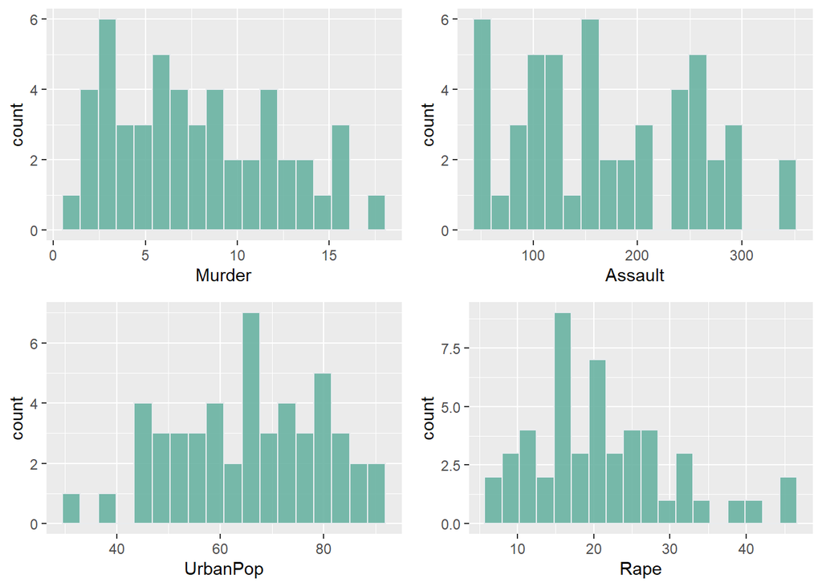

```r
arr.colnames = arrests_df %>%
  colnames()
graphs = list()
for (j in (1:ncol(arrests_df))){
  graphs[[j]] = arrests_df %>%
  ggplot(aes_string(x = arr.colnames[j])) +
  geom_histogram(bins = 18, fill="#69b3a2", color="#e9ecef", alpha=0.9)
}
hist.arr = do.call(grid.arrange, graphs)
```

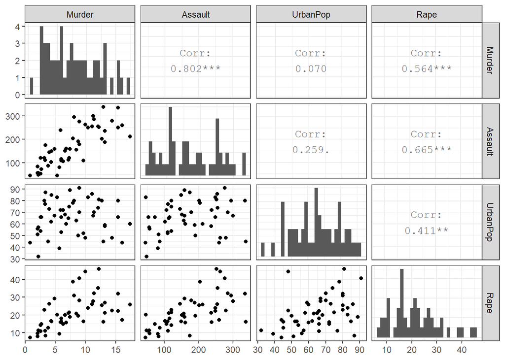

```r
mult.arr = ggpairs(arrests_df, diag = list(continuous = "barDiag")) + theme_bw()
mult.arr
```

Creating some boxplots:

```r
# melting dataframe
melted_df = melt(arrests_df)
```

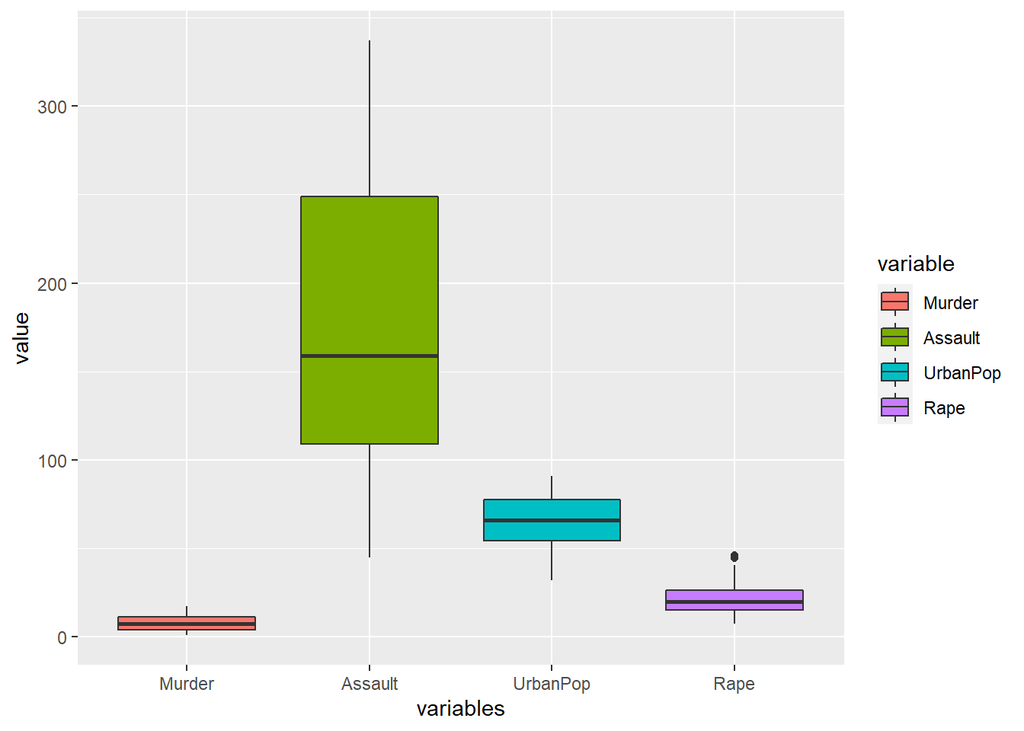

```r
melted_df %>% ggplot(aes(x = variable, y = value, fill = variable)) +
  geom_boxplot() +
  xlab("variables")
```

Plotting the heatmatrix of correlations

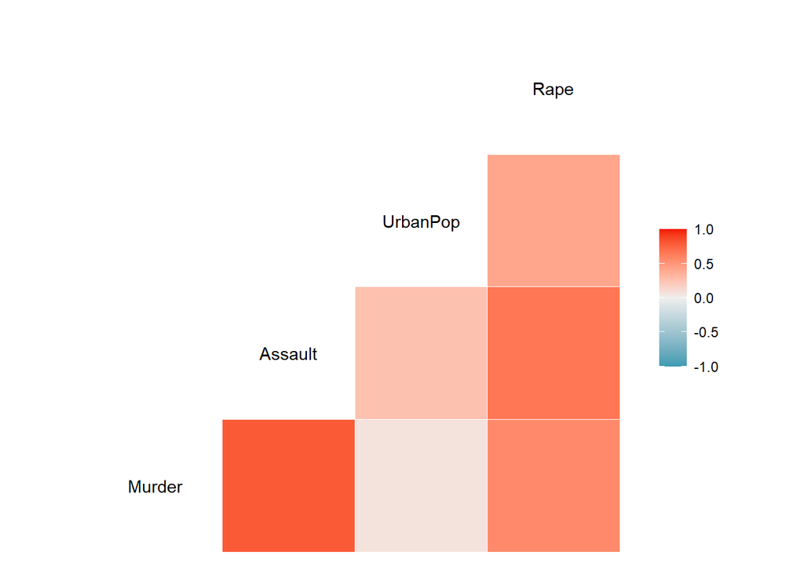

```r
ggcorr(arrests_df, method = c("everything", "pearson"))
```

Applying some hierarchical clustering and k-means methods in the data. But first, we will compute some dissimilarity matrix and evaluate them.

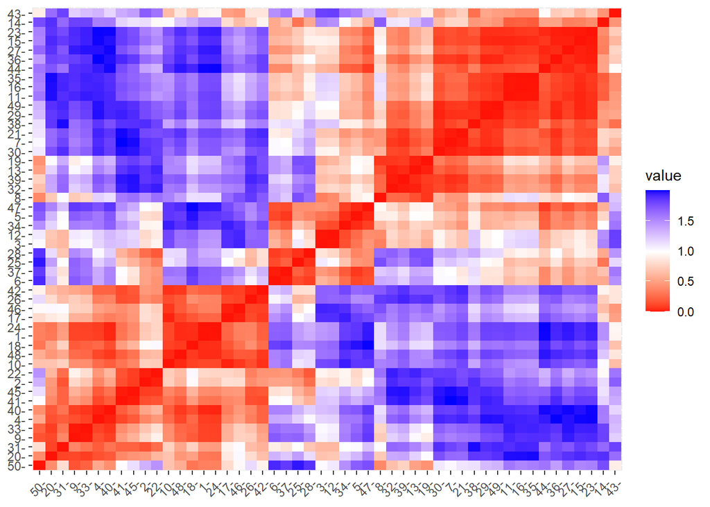

```r
# scaling the data
arrests_df = arrests_df %>%
  scale()

arr.eucl_dist = get_dist(arrests_df, method = "euclidean")
arr.pearson_dist = get_dist(arrests_df, method = "pearson")
fviz_dist(arr.pearson_dist)
```

Now computing all clustering methods using eclust (good to make other graphs).

```r
# computing diana
arr.diana = arrests_df %>%
  eclust(FUNcluster = "diana", hc_metric = "euclidean")

# computing agglomerative hclust with average linkage and ward linkage
arr.av_hc = arrests_df %>%
  eclust(FUNcluster = "hclust", hc_method = "average")

arr.wd_hc = arrests_df %>%
  eclust(FUNcluster = "hclust", hc_method = "ward.D2")


# computing agnes (agglomerative nesting (Hierarchical Clustering)) with ward linkage
arr.agnes = arrests_df %>%
  eclust(FUNcluster = "agnes", hc_metric = "euclidean")

# computing k-means
arr.km = arrests_df %>%
  eclust(FUNcluster = "kmeans", nstart = 25)
```

[figure not shown]

```r
hc_list = list('Average linkage' = arr.av_hc,
               'Ward linkage' = arr.wd_hc,
               'Agnes' = arr.agnes,
               'Diana' = arr.diana)
```

Assessing the optimal number of clusters in k-means according to gap statistics, silhouette plot and elbow method.

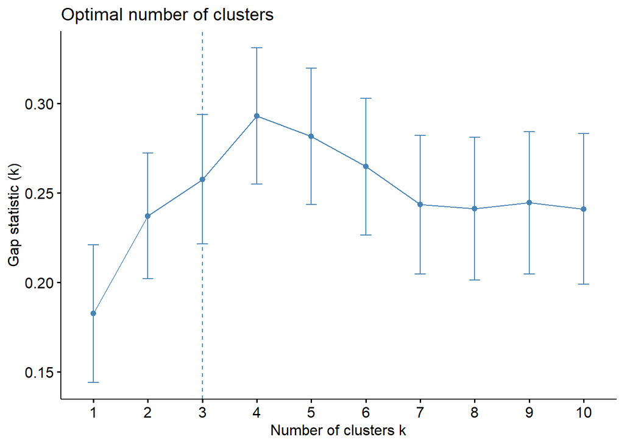

```r
fviz_gap_stat(arr.km$gap_stat)
```

```r
arr.km$nbclust
```

```
## [1] 3
```

```
##   cluster size ave.sil.width
## 1       1   13          0.37
## 2       2   20          0.26
## 3       3   17          0.32
```

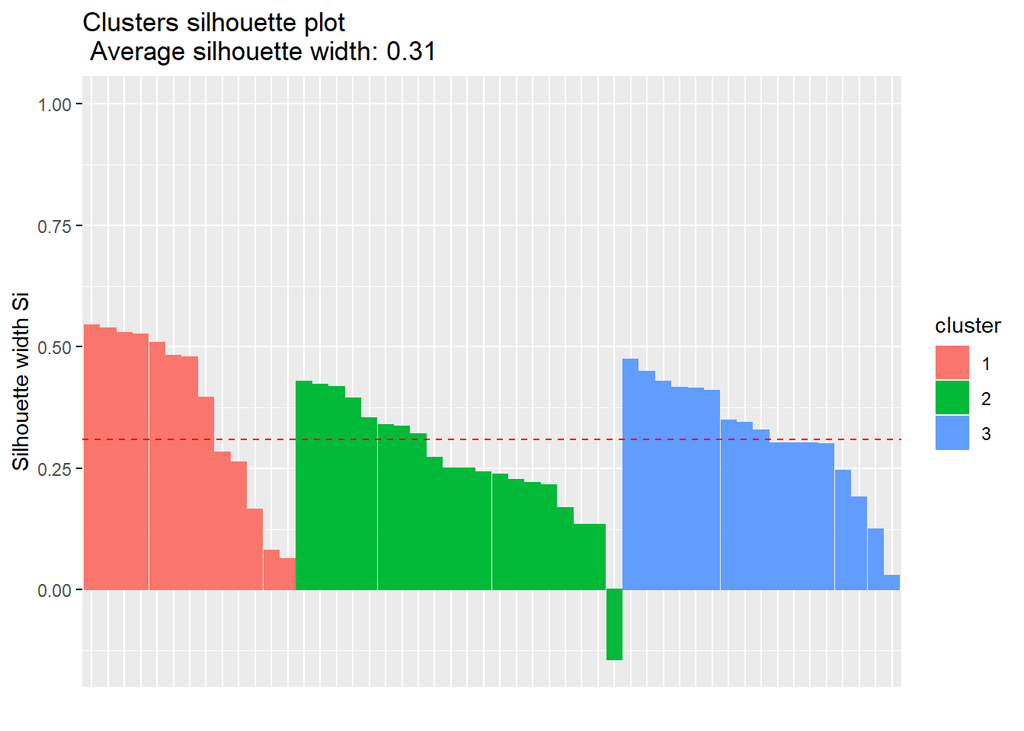

```r
fviz_silhouette(arr.km)
```

but, we can investigate the problem of determining the optimal number of clusters more further, plotting some scores and methods for each number of clusters in between 1 and 10 clusters. Inittialy, we analyse the optimal number of clusters according to the silhouette method:

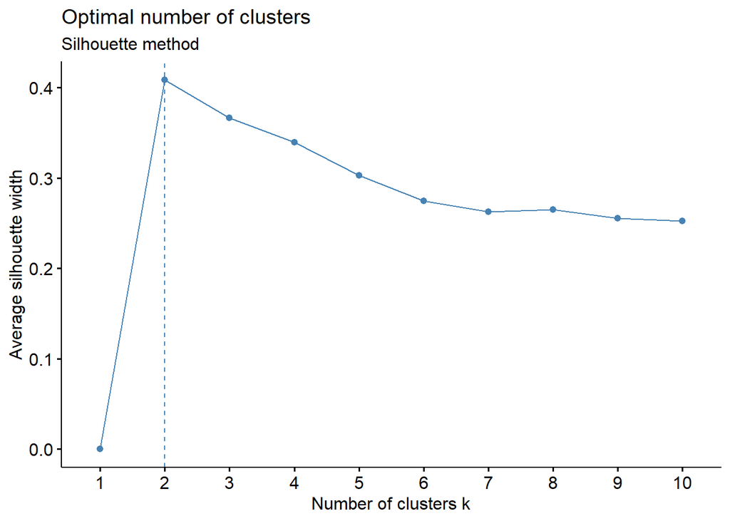

```r
fviz_nbclust(arrests_df, kmeans, method = "silhouette") +
  labs(subtitle = "Silhouette method")
```

Assessing the number of clusters using the Elbow method:

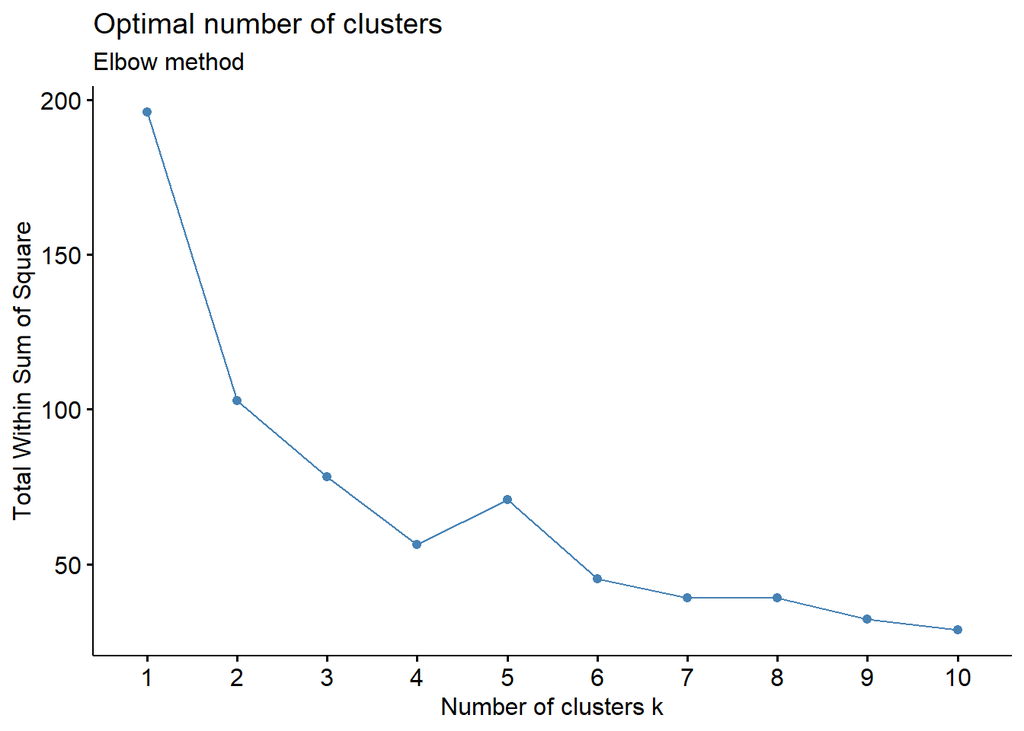

```r
fviz_nbclust(arrests_df, kmeans, method = "wss") +
  labs(subtitle = "Elbow method")
```

```r
km.stats = cluster.stats(arr.eucl_dist, arr.km$cluster)
print(km.stats$dunn)
```

```
## [1] 0.1194345
```

```r
print(km.stats$dunn2)
```

```
## [1] 1.067916
```

```r
print(km.stats$avg.silwidth)
```

```
## [1] 0.3094312
```

And the indices distribution, which points out the amount of indices that recommend each $k$ as the optimal number of clusters.

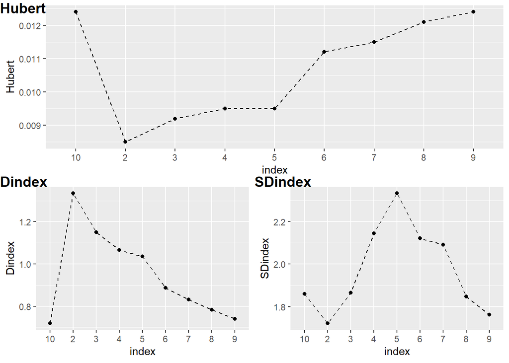

```r
plot1 <- km.index %>%
  ggplot(aes(x = index, y  = Hubert, group = 1)) +
  geom_line(linetype = "dashed") +
  geom_point()


plot2 <- km.index %>%
  ggplot(aes(x = index, y = Dindex, group = 1))+
  geom_line(linetype = "dashed")+
  geom_point()

plot3 <- km.index %>%
  ggplot(aes(x = index, y = SDindex, group = 1))+
  geom_line(linetype = "dashed")+
  geom_point()

ggarrange(plot1, ggarrange(plot2, plot3, labels = c("Dindex", "SDindex"),
                           hjust = c(0,0), vjust = c(0.5, 0.5)),
          labels = "Hubert", nrow = 2, hjust = 0,
          vjust = 1.25)
```

This frequency distribution can be seen in the graph below:

```
## Among all indices:
## ===================
## * 2 proposed  0 as the best number of clusters
## * 11 proposed  2 as the best number of clusters
## * 2 proposed  3 as the best number of clusters
## * 1 proposed  4 as the best number of clusters
## * 1 proposed  5 as the best number of clusters
## * 7 proposed  6 as the best number of clusters
## * 1 proposed  9 as the best number of clusters
## * 1 proposed  10 as the best number of clusters
##
## Conclusion
## =========================
## * According to the majority rule, the best number of clusters is  2 .
```

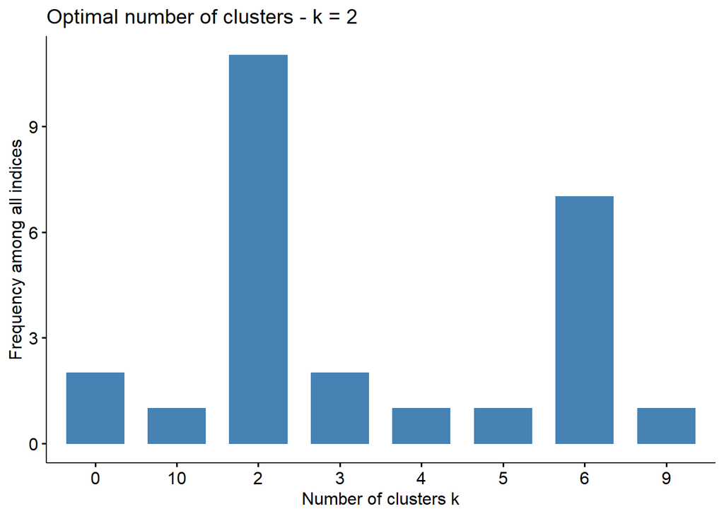

```r
fviz_nbclust(km.nbclust, ggtheme = theme_minimal())
```

Plotting Kmeans clustering with $k = 2$

```r
arr.km2 = eclust(arrests_df, FUNcluster = "kmeans", k = 2)
```

[figure not shown]

Computing the average silhouette and dunn measures for $k = 2$:

```r
km.stats = cluster.stats(arr.eucl_dist, arr.km2$cluster)
print(km.stats$dunn)
```

```
## [1] 0.2214287
```

```r
print(km.stats$dunn2)
```

```
## [1] 1.60725
```

```r
print(km.stats$avg.silwidth)
```

```
## [1] 0.408489
```

We also can work with hiearchical clustering methods and assess them. The following dendrograms are generated by each hierachical method chosen.

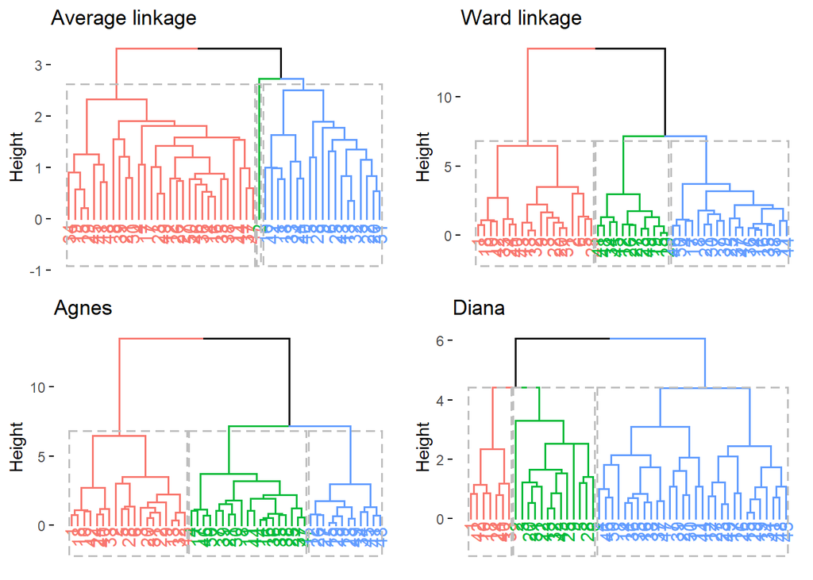

```r
plot_list = list()
for (i in (1:length(hc_list))){
  plot_list[[i]] = fviz_dend(hc_list[[i]], rect = TRUE,
                             main = names(hc_list)[i])
}
hc_dends = do.call(grid.arrange, plot_list)
```

```r
hc_dends
```

With each correspondent silhouette plot and silhouette average width for $k = 3$

```r
plot_list = list()
for(i in (1:length(hc_list))){
  plot_list[[i]] = fviz_silhouette(hc_list[[i]], main = names(hc_list)[i])
}
```

```
##   cluster size ave.sil.width
## 1       1   19          0.24
## 2       2    1          0.00
## 3       3   30          0.43
##   cluster size ave.sil.width
## 1       1   19          0.26
## 2       2   19          0.28
## 3       3   12          0.43
##   cluster size ave.sil.width
## 1       1   19          0.26
## 2       2   19          0.28
## 3       3   12          0.43
##   cluster size ave.sil.width
## 1       1    7          0.45
## 2       2   13          0.31
## 3       3   30          0.38
```

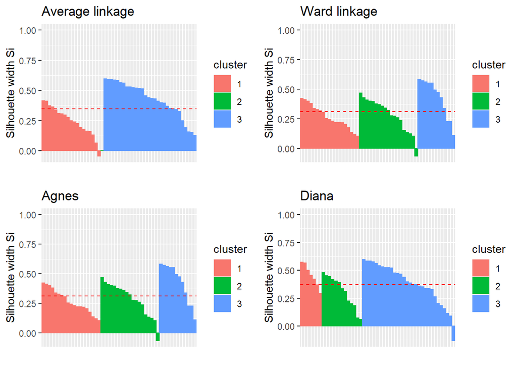

```r
hc_sill = do.call(grid.arrange, plot_list)
```

And average silhouette width of each hiearchical clustering method

```r
sil_list = list()
for(i in (1:length(hc_list))){
  silinfo = hc_list[[i]]$silinfo
  sil_list[names(hc_list)[i]] = silinfo$avg.width
}
print(sil_list)
```

```
## $`Average linkage`
## [1] 0.3486368
##
## $`Ward linkage`
## [1] 0.3103636
##
## $Agnes
## [1] 0.3103636
##
## $Diana
## [1] 0.3734234
```

Now, concerning the optimum number of clusters for each method, we initially repeat all the plots made above for hierarchical methods, starting with: *Gap statistics*

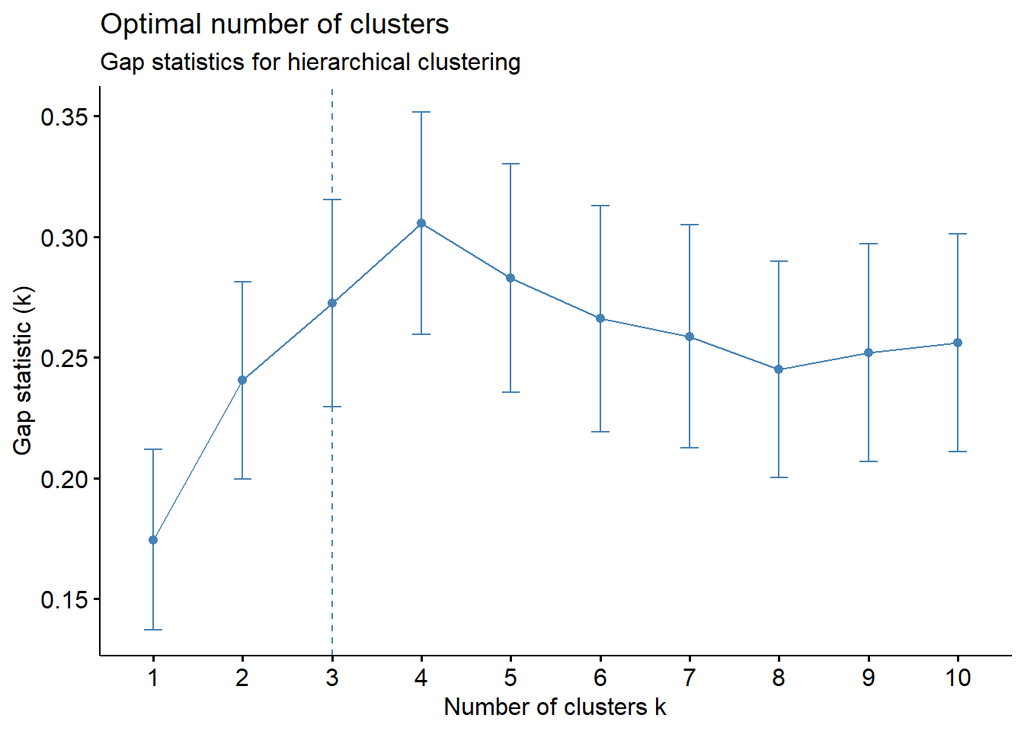

```r
 fviz_gap_stat(hc_list[[1]]$gap_stat) +
    labs(subtitle = "Gap statistics for hierarchical clustering")
```

*Silhouette method*

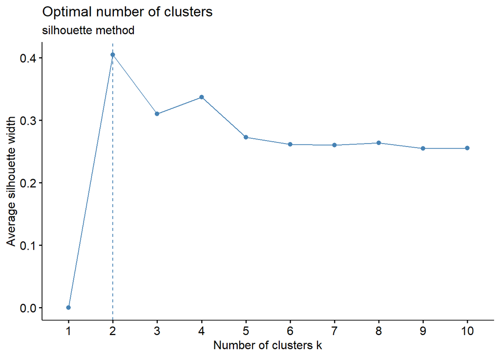

```r
fviz_nbclust(arrests_df, FUNcluster = hcut, method = "silhouette") +
  labs(subtitle = "silhouette method")
```

*Elbow method*

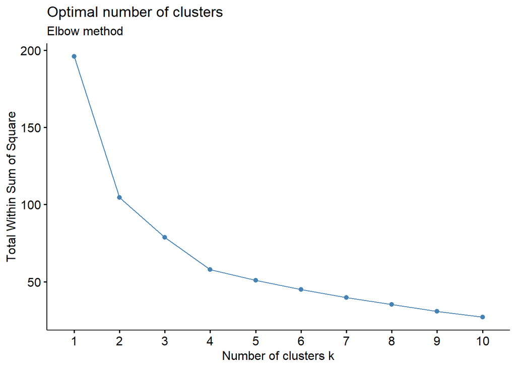

```r
fviz_nbclust(arrests_df, FUNcluster = hcut, method = "wss") +
  labs(subtitle = "Elbow method")
```

Which gives us a hint that $k = 2$ is somewhat an interesting choice for the number of clusters in the hierarchical methods. Now, we analyse the frequency of each optimum $k$

```r
hc.nbclust= NbClust(data = arrests_df, distance = "euclidean", min.nc = 2, max.nc = 10, method = "ward.D2")
```

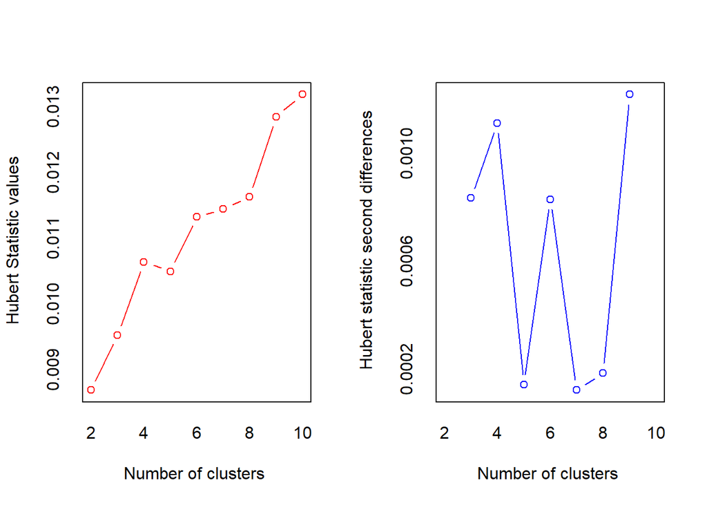

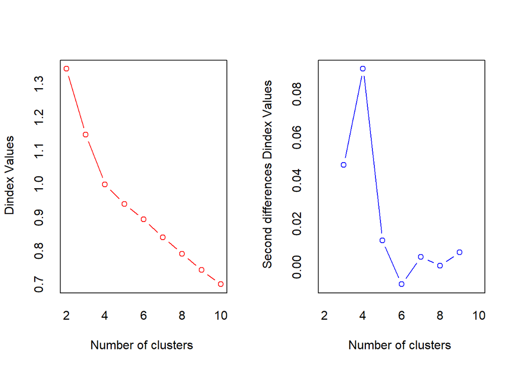

```r
hc.index = data.frame(hc.nbclust$All.index)
hc.index$index = row.names(hc.index)
```

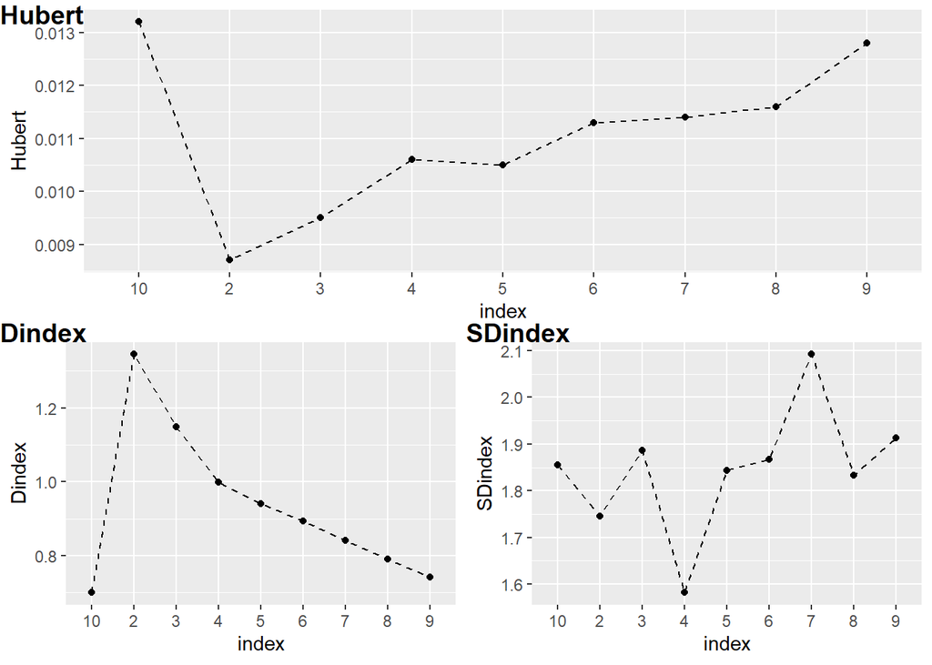

```r
plot1 <- hc.index %>%
  ggplot(aes(x = index, y  = Hubert, group = 1)) +
  geom_line(linetype = "dashed") +
  geom_point()


plot2 <- hc.index %>%
  ggplot(aes(x = index, y = Dindex, group = 1))+
  geom_line(linetype = "dashed")+
  geom_point()

plot3 <- hc.index %>%
  ggplot(aes(x = index, y = SDindex, group = 1))+
  geom_line(linetype = "dashed")+
  geom_point()

ggarrange(plot1, ggarrange(plot2, plot3, labels = c("Dindex", "SDindex"),
                           hjust = c(0,0), vjust = c(0.5, 0.5)),
          labels = "Hubert", nrow = 2, hjust = 0,
          vjust = 1.25)
```

[output not shown]

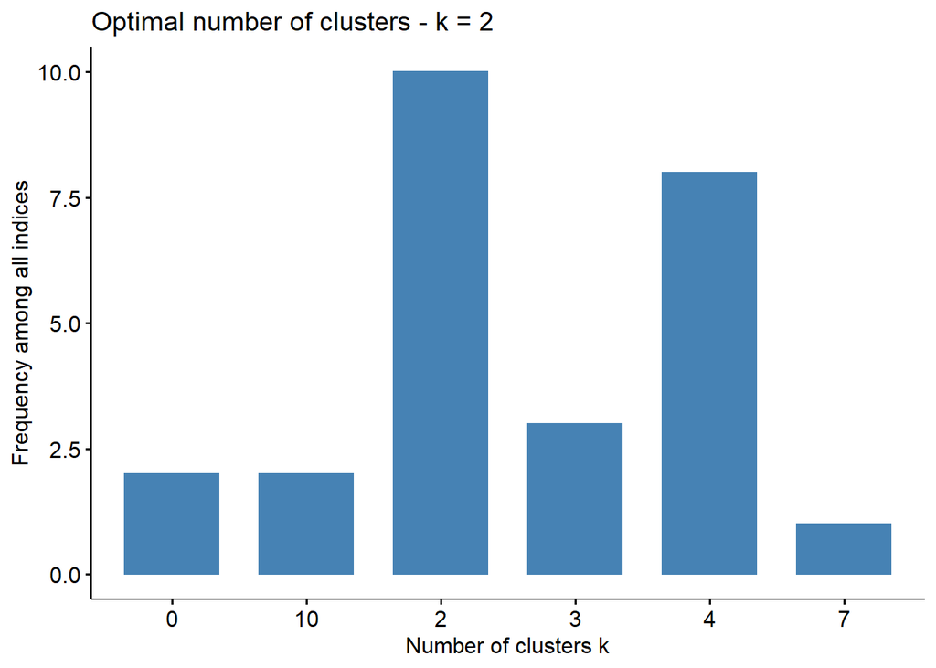

```r
fviz_nbclust(hc.nbclust, ggtheme = theme_minimal())
```

Giving the same result as revealed above for K-means. But, apart from only assessing the number of clusters, we will now make internal cluster validation, seeeking the best clustering methods according to each measure of each type of validation. So, we will analyse graphically some clustering validations methods assessing:  
*stability*

```r
cl_methods = c("hierarchical", "agnes" , "diana", "kmeans")
n = 2:10
better_stability = clValid(arrests_df, n, cl_methods,validation = "stability" ,metric = "euclidean", method = "ward")
optim.stab = optimalScores(better_stability)

# trying to plot using ggplot
# first converting the data to data frame
str(better_stability)
measures = better_stability@measures
```

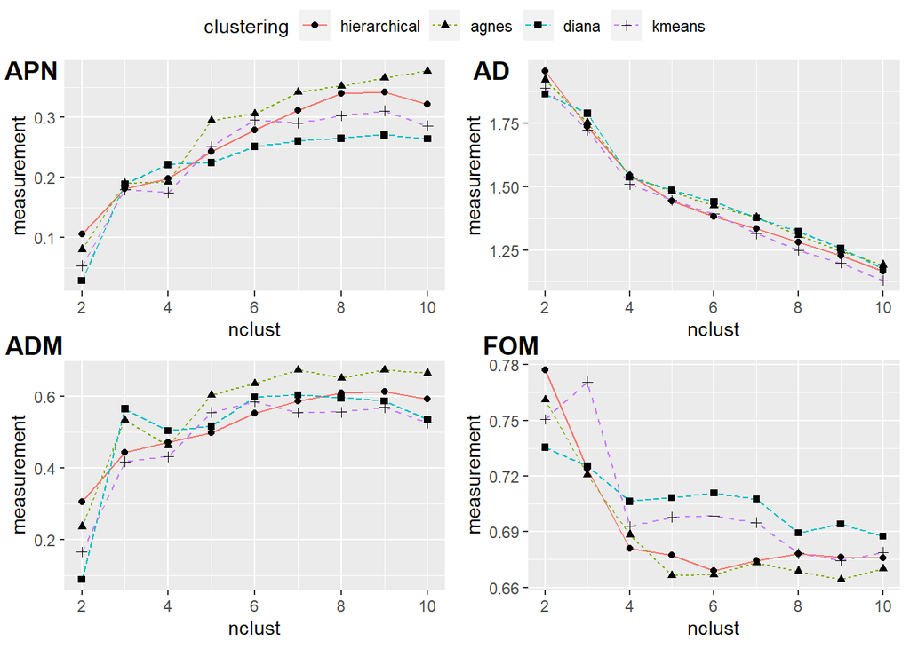

```r
for (i in 1:length(cl_methods)){
  local_measure = measures[, , cl_methods[i]]
  names.row = rownames(local_measure)
  names.col = colnames(local_measure)
  for (j in 1:nrow(local_measure)){
  rep.clustering = rep(cl_methods[i], ncol(local_measure))
  rep.row = rep(names.row[j],ncol(local_measure))
  row = local_measure[j, 1:length(n)]
  col.names = as.integer(names(row))
  if (j == 1 && i == 1){
  stab.data = data.frame("clustering" = rep.clustering,
                    "type" = rep.row,
                    "nclust" = col.names,
                    "measurement" = row)
  }
  else{
    new_data = data.frame("clustering" = rep.clustering,
                    "type" = rep.row,
                    "nclust" = col.names,
                    "measurement" = row)
    stab.data = bind_rows(stab.data, new_data)
  }
  }
}

plot1 <- stab.data %>%
  filter( type == "APN") %>%
  ggplot( aes(x = nclust, y  = measurement, group = clustering)) +
  geom_line(aes(linetype = clustering, color = clustering)) +
  geom_point(aes(shape = clustering))

plot2 <- stab.data %>%
  filter( type == "AD") %>%
  ggplot( aes(x = nclust, y  = measurement, group = clustering)) +
  geom_line(aes(linetype = clustering, color = clustering)) +
  geom_point(aes(shape = clustering))

plot3 <- stab.data %>%
  filter( type == "ADM") %>%
  ggplot( aes(x = nclust, y  = measurement, group = clustering)) +
  geom_line(aes(linetype = clustering, color = clustering)) +
  geom_point(aes(shape = clustering))

plot4 <- stab.data %>%
  filter( type == "FOM") %>%
  ggplot( aes(x = nclust, y  = measurement, group = clustering)) +
  geom_line(aes(linetype = clustering, color = clustering)) +
  geom_point(aes(shape = clustering))


ggarrange(plot1, plot2, plot3, plot4, labels = c("APN", "AD", "ADM", "FOM"),
          ncol = 2, nrow = 2, hjust = c(-0.1, -0.5, -0.1, -0.5),
          vjust = c(1.5, 1.5, 0.25, 0.25), common.legend = TRUE)
```

with the respective optimum statistics:

```r
print(optim.stab)
```

```
##          Score Method Clusters
## APN 0.02833333  diana        2
## AD  1.12903110 kmeans       10
## ADM 0.08740392  diana        2
## FOM 0.66414278  agnes        9
```

*internal measures*

```r
better_internal_measures = clValid(arrests_df, n, cl_methods,validation = "internal" ,metric = "euclidean", method = "ward")
optim.intern = optimalScores(better_internal_measures)
str(better_internal_measures)
measures = better_internal_measures@measures
```

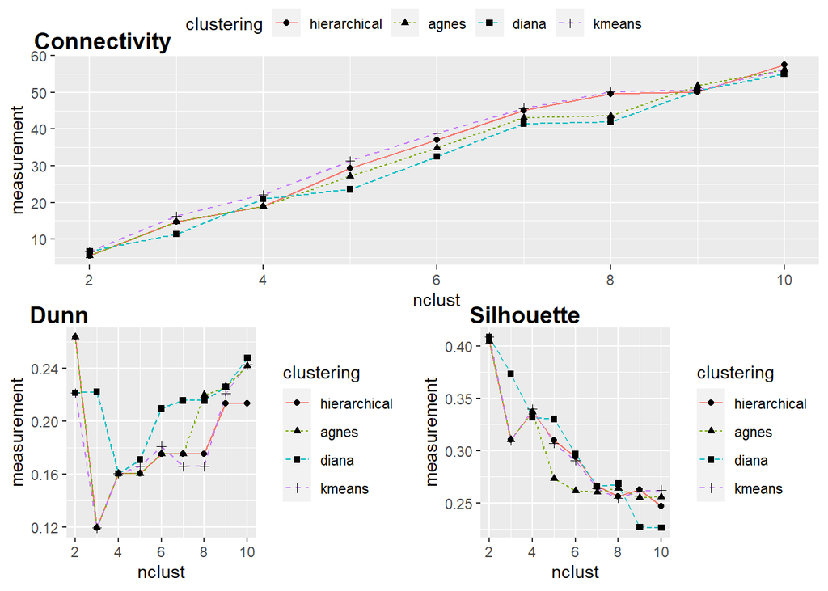

```r
for (i in 1:length(cl_methods)){
  local_measure = measures[, , cl_methods[i]]
  names.row = rownames(local_measure)
  names.col = colnames(local_measure)
  for (j in 1:nrow(local_measure)){
  rep.clustering = rep(cl_methods[i], ncol(local_measure))
  rep.row = rep(names.row[j],ncol(local_measure))
  row = local_measure[j, 1:length(n)]
  col.names = as.integer(names(row))
  if (j == 1 && i == 1){
  intern.data = data.frame("clustering" = rep.clustering,
                    "type" = rep.row,
                    "nclust" = col.names,
                    "measurement" = row)
  }
  else{
    new_data = data.frame("clustering" = rep.clustering,
                    "type" = rep.row,
                    "nclust" = col.names,
                    "measurement" = row)
    intern.data = bind_rows(intern.data, new_data)
  }
  }
}

plot1 <- intern.data %>%
  filter( type == "Connectivity") %>%
  ggplot( aes(x = nclust, y  = measurement, group = clustering)) +
  geom_line(aes(linetype = clustering, color = clustering)) +
  geom_point(aes(shape = clustering))

plot2 <- intern.data %>%
  filter( type == "Dunn") %>%
  ggplot( aes(x = nclust, y  = measurement, group = clustering)) +
  geom_line(aes(linetype = clustering, color = clustering)) +
  geom_point(aes(shape = clustering))

plot3 <- intern.data %>%
  filter( type == "Silhouette") %>%
  ggplot( aes(x = nclust, y  = measurement, group = clustering)) +
  geom_line(aes(linetype = clustering, color = clustering)) +
  geom_point(aes(shape = clustering))


ggarrange(plot1,
             ggarrange(plot2, plot3, ncol = 2, labels = c("Dunn", "Silhouette"),
                       vjust = c(0.25, 0.25)),
             nrow = 2, labels = "Connectivity", vjust = 0.15,
          hjust = -0.25, common.legend = TRUE)
```

with the respective optimum statistics:

```r
print(optim.intern)
```

```
##                  Score       Method Clusters
## Connectivity 5.5210317 hierarchical        2
## Dunn         0.2636646 hierarchical        2
## Silhouette   0.4084890        diana        2
```

```r
league_df = read.csv("datasets/total_data_na.csv") %>%
  tibble()
league_df
```

```
## # A tibble: 143 x 25
##    PLAYER Mat.x Inns.x    NO Runs.x    HS Avg.x    BF  SR.x  X100   X50   X4s
##    <fct>  <int>  <int> <int>  <int> <int> <fct> <int> <dbl> <int> <int> <int>
##  1 Aaron~    10      9     1    134    46 16.75   100 134       0     0     6
##  2 AB de~    12     11     2    480    90 53.33   275 175.      0     6    39
##  3 Abhis~     3      3     2     63    46 63       33 191.      0     0     3
##  4 Ajink~    15     14     1    370    65 28.46   313 118.      0     1    39
##  5 Alex ~     6      6     0    148    45 24.66   118 125.      0     0    13
##  6 Ambat~    16     16     2    602   100 43      402 150.      1     3    53
##  7 Andre~    16     14     3    316    88 28.72   171 185.      0     1    17
##  8 Andre~    14      8     2     32    14 5.33     38  84.2     0     0     2
##  9 Axar ~     9      8     2     80    19 13.33    69 116.      0     0     3
## 10 Ben C~     9      6     2     96    37 24       58 166.      0     0     5
## # ... with 133 more rows, and 13 more variables: X6s <int>, Mat.y <int>,
## #   Inns.y <int>, Ov <dbl>, Runs.y <int>, Wkts <int>, BBI <int>, Avg.y <fct>,
## #   Econ <dbl>, SR.y <fct>, X4w <int>, X5w <int>, y <int>
```

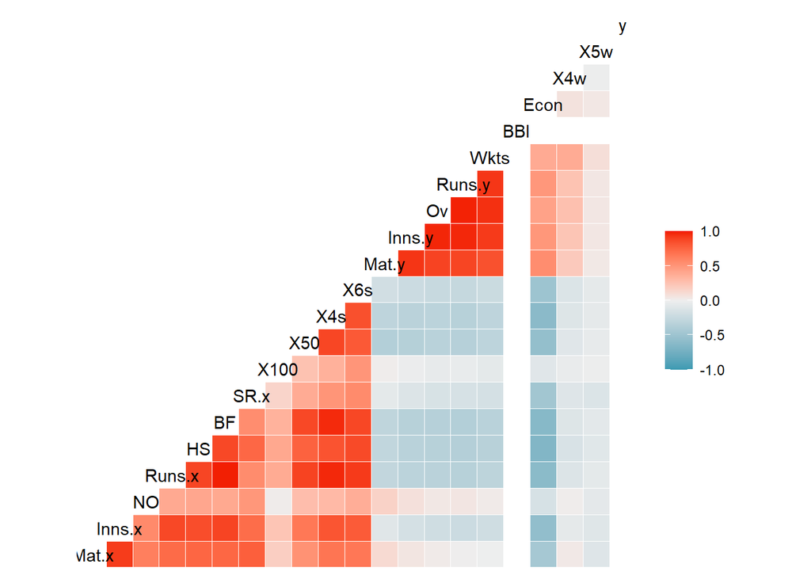

```r
ggcorr(league_df %>%
         select(-c(PLAYER)), method = c("everything", "pearson"))
```

Removing variable y and BBI

```r
league_df = league_df %>%
  select(-c(y, BBI))
```

```r
# substituing missing values by mean and scaling
league_df = league_df %>%
 mutate(Avg.x = as.numeric(as.character(Avg.x)),
               Avg.y =as.numeric(as.character(Avg.y)),
          SR.y = as.numeric(as.character(SR.y))) %>%
  mutate(across(where(is.numeric), zoo::na.aggregate)) %>%
  mutate(across(-c(PLAYER), scale))
league_df
```

```
## # A tibble: 143 x 23
##    PLAYER Mat.x[,1] Inns.x[,1] NO[,1] Runs.x[,1] HS[,1] Avg.x[,1]  BF[,1]
##    <fct>      <dbl>      <dbl>  <dbl>      <dbl>  <dbl>     <dbl>   <dbl>
##  1 Aaron~     0.446    0.543   -0.155    0.00940  0.402   -0.0392  0.0413
##  2 AB de~     0.776    0.907    0.459    1.98     1.78     2.14    1.50
##  3 Abhis~    -0.705   -0.548    0.459   -0.395    0.402    2.72   -0.516
##  4 Ajink~     1.27     1.45    -0.155    1.35     0.996    0.658   1.81
##  5 Alex ~    -0.212   -0.00254 -0.768    0.0892   0.371    0.432   0.191
##  6 Ambat~     1.43     1.82     0.459    2.68     2.09     1.52    2.55
##  7 Andre~     1.43     1.45     1.07     1.05     1.72     0.674   0.632
##  8 Andre~     1.10     0.361    0.459   -0.572   -0.599   -0.719  -0.474
##  9 Axar ~     0.282    0.361    0.459   -0.298   -0.443   -0.243  -0.216
## 10 Ben C~     0.282   -0.00254  0.459   -0.207    0.120    0.393  -0.308
## # ... with 133 more rows, and 15 more variables: SR.x[,1] <dbl>,
## #   X100[,1] <dbl>, X50[,1] <dbl>, X4s[,1] <dbl>, X6s[,1] <dbl>,
## #   Mat.y[,1] <dbl>, Inns.y[,1] <dbl>, Ov[,1] <dbl>, Runs.y[,1] <dbl>,
## #   Wkts[,1] <dbl>, Avg.y[,1] <dbl>, Econ[,1] <dbl>, SR.y[,1] <dbl>,
## #   X4w[,1] <dbl>, X5w[,1] <dbl>
```

Now, we can analyse clustering tendencies, and how clusterable the data is (accordinto to hopkins statistics)

```r
gradient.color = list(low = "steelblue", high = "white")
clust_tend.league = league_df[, -1] %>%
  get_clust_tendency(n = 100, gradient = gradient.color)
```

with the following hopkins statistics:

```r
clust_tend.league$hopkins_stat
```

```
## [1] 0.8652321
```

and with respective trend plot:

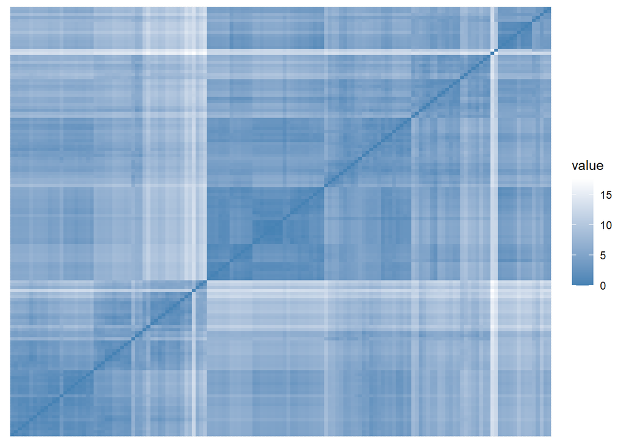

```r
clust_tend.league$plot
```

The hopkins statistics and the plot show that our current data is very clusterable. So, we can move forward with a cluster analysis of the data similar to the previous one:

```r
# computing diana
league.names = league_df[1]
league_df = league_df %>%
  select(-c(PLAYER))

league.diana = league_df %>%
  eclust(FUNcluster = "diana", hc_metric = "euclidean")

# computing agglomerative hclust with ward linkage
league.wd_hc = league_df %>%
  eclust(FUNcluster = "hclust", hc_method = "ward.D2")


# computing agnes (agglomerative nesting (Hierarchical Clustering)) with ward linkage
league.agnes = league_df %>%
  eclust(FUNcluster = "agnes", hc_metric = "euclidean")

# computing k-means
league.km = league_df %>%
  eclust(FUNcluster = "kmeans", nstart = 25)
```

[figure not shown]

```r
clust_list = list('K means' = league.km,
               'Ward linkage' = league.wd_hc,
               'Agnes' = league.agnes,
               'Diana' = league.diana)
```

assessing the optimal number of clusters in all chosen clustering techiniques accordingo to: *Gap statistics*

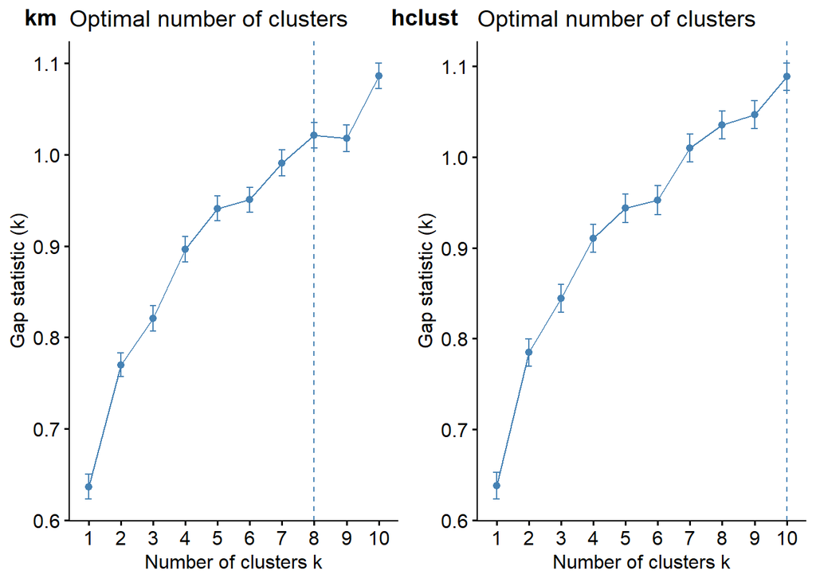

```r
km.gap = fviz_gap_stat(league.km$gap_stat)
hc.gap = fviz_gap_stat(league.wd_hc$gap_stat)
ggarrange(km.gap, hc.gap, labels = c("km", "hclust"), hjust = c(-0.75, 0.25))
```

*Silhouette*

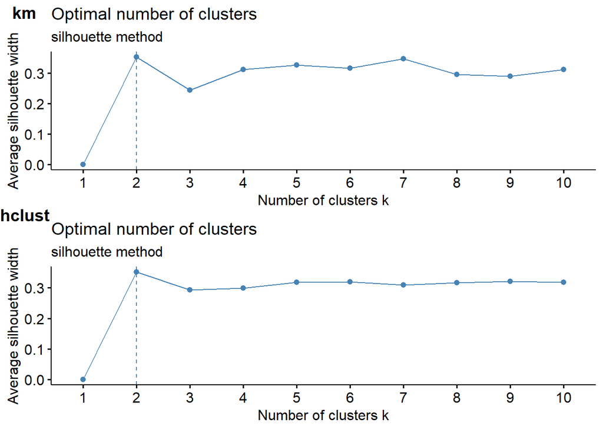

```r
sil.km = fviz_nbclust(league_df, FUNcluster = kmeans, method = "silhouette") +
  labs(subtitle = "silhouette method")
sil.hc= fviz_nbclust(league_df, FUNcluster = hcut, method = "silhouette") +
  labs(subtitle = "silhouette method")

ggarrange(sil.km, sil.hc, labels = c("km", "hclust"), hjust = c(-0.5, 0),nrow = 2,
          vjust = c(1.5, 0.5))
```

*Elbow method*

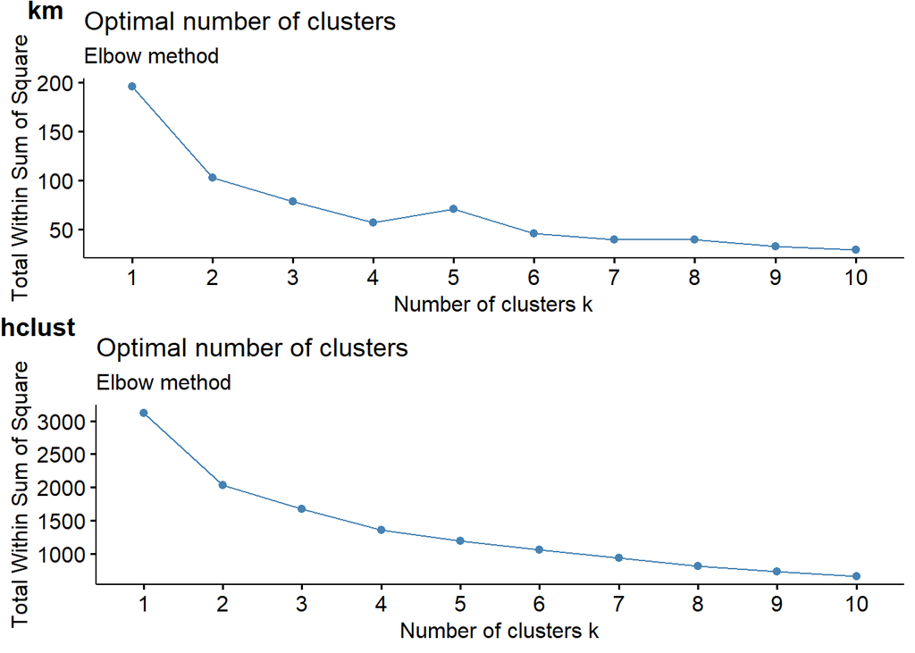

```r
hc.elbow = fviz_nbclust(league_df, FUNcluster = hcut, method = "wss") +
  labs(subtitle = "Elbow method")

km.elbow = fviz_nbclust(arrests_df, FUNcluster = kmeans, method = "wss") +
  labs(subtitle = "Elbow method")

ggarrange(km.elbow, hc.elbow, labels = c("km", "hclust"), hjust = c(-0.75, 0),nrow = 2,
          vjust = c(1, 0.5))
```

*Silhouette plot*

```r
plot_list = list()
for(i in (1:length(clust_list))){
  plot_list[[i]] = fviz_silhouette(clust_list[[i]], main = names(clust_list)[i])
}
```

```
##   cluster size ave.sil.width
## 1       1   19          0.27
## 2       2   18          0.26
## 3       3   17          0.18
## 4       4    3          0.05
## 5       5   13          0.38
## 6       6    1          0.00
## 7       7   34          0.40
## 8       8   38          0.45
##    cluster size ave.sil.width
## 1        1   22          0.50
## 2        2   13          0.32
## 3        3   13          0.14
## 4        4    4          0.25
## 5        5   21          0.24
```

[output cut: 27 more lines]